# Mapping and Plotting

#### *Example #9: Combining xts and ggplot2*

The xts package is good for working with time series data, while ggplot2 is strong for customizing plots. The packages can be combined in using the weather data.

Example code includes:

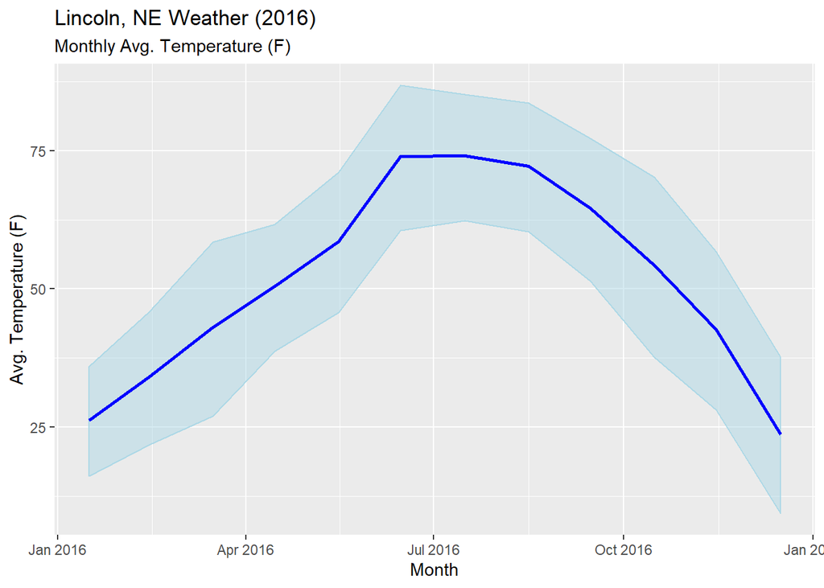

```r
# Create an XTS for temperature and dewpoint data
tdXTS <- xts(select(tdData, minT, meanT, maxT, minD, meanD, maxD), order.by=tdData$date)

# Use xts for monthly average and ggplot2 for plotting
basePlot <- tdXTS %>%
    apply.monthly(FUN=mean, na.rm=TRUE) %>%
    data.frame(date=index(.), row.names=NULL) %>%
    ggplot(aes(x=date-lubridate::days(15))) +
    geom_ribbon(aes(ymin=minT, ymax=maxT), color="lightblue", fill="lightblue", alpha=0.5) +
    geom_line(aes(y=meanT), color="blue", lwd=1) +
    labs(x="Month", y="Avg. Temperature (F)", title="Lincoln, NE Weather (2016)",
         subtitle="Monthly Avg. Temperature (F)"
         )
basePlot
```

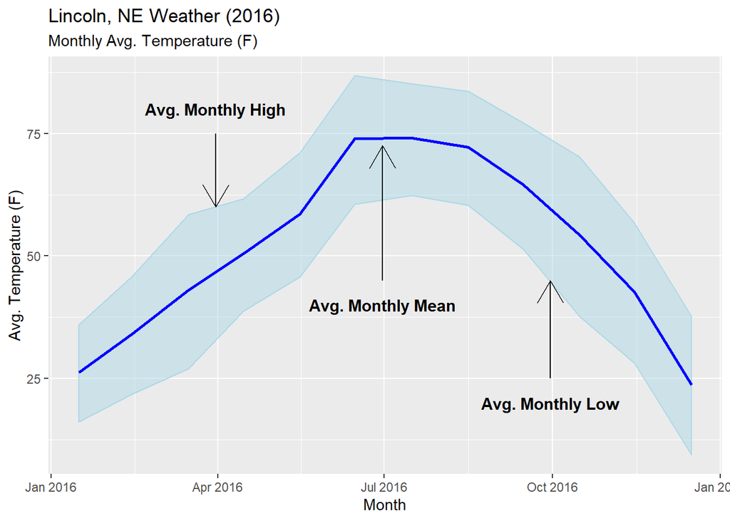

```r
# Add labelling for the three elements
hiMonth <- index(tdXTS %>% apply.monthly(FUN=mean))[3]
loMonth <- index(tdXTS %>% apply.monthly(FUN=mean))[9]
muMonth <- index(tdXTS %>% apply.monthly(FUN=mean))[6]
hiPoint <- c(60, 75)
loPoint <- c(45, 25)
muPoint <- c(72.5, 45)

labFrame <- data.frame(x=c(hiMonth, loMonth, muMonth),
                       yend=c(hiPoint[1], loPoint[1], muPoint[1]),
                       y=c(hiPoint[2], loPoint[2], muPoint[2]),
                       text=c("Avg. Monthly High", "Avg. Monthly Low", "Avg. Monthly Mean")) %>%
    mutate(xend=x)

basePlot +
    geom_segment(data=labFrame, aes(x=x, y=y, xend=xend, yend=yend), arrow=arrow()) +
    geom_text(data=labFrame, aes(x=x, y=y+c(5, -5, -5), label=text), fontface="bold", size=4)
```

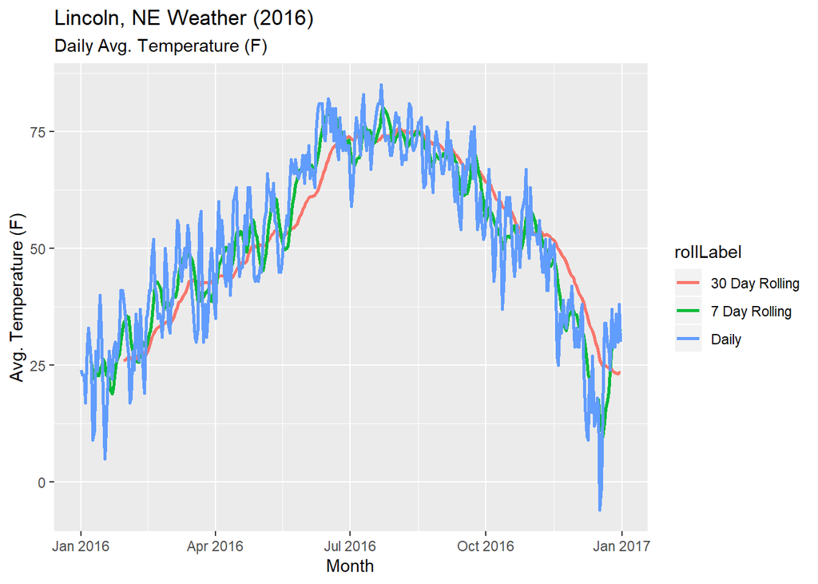

```r
# Can also create and plot a custom rolling average
baseData <- tdXTS %>%
    data.frame(date=index(.), row.names=NULL)

base7Day <- rollapply(tdXTS, 7, FUN=mean, na.rm=TRUE) %>%
    data.frame(date=index(.), row.names=NULL)

base30Day <- rollapply(tdXTS, 30, FUN=mean, na.rm=TRUE) %>%
    data.frame(date=index(.), row.names=NULL)

plotFrame <- bind_rows(baseData, base7Day, base30Day, .id="rolling") %>%
    mutate(rollLabel=case_when(rolling==1 ~ "Daily",
                               rolling==2 ~ "7 Day Rolling",
                               rolling==3 ~ "30 Day Rolling",
                               TRUE ~ "ERROR"
                               )
           )

plotFrame %>%
    ggplot(aes(x=date)) +
    geom_line(aes(y=meanT, color=rollLabel, group=rollLabel), lwd=1) +
    labs(x="Month", y="Avg. Temperature (F)", title="Lincoln, NE Weather (2016)",
         subtitle="Daily Avg. Temperature (F)"
         )
```

#### *Example #10: Plotting Weather Data (Humidity)*

Humidity data are also available in the lincoln_weather dataset. There is a relationship between temperature, dewpoint, and humidity.

Example code includes:

```r
htdData <- lincoln_weather %>%
    select(CST, meanT=`Mean Temperature [F]`, meanD=`Mean Dew Point [F]`, meanH=`Mean Humidity`) %>%
    mutate(date=as.Date(CST), month=lubridate::month(date))
str(htdData)
```

```
## Classes 'tbl_df', 'tbl' and 'data.frame':    366 obs. of  6 variables:
##  $ CST  : chr  "2016-1-1" "2016-1-2" "2016-1-3" "2016-1-4" ...
##  $ meanT: int  24 23 23 17 29 33 30 25 9 11 ...
##  $ meanD: int  13 14 15 13 25 32 30 22 4 5 ...
##  $ meanH: int  68 72 73 82 83 91 96 85 77 75 ...
##  $ date : Date, format: "2016-01-01" "2016-01-02" ...
##  $ month: num  1 1 1 1 1 1 1 1 1 1 ...
```

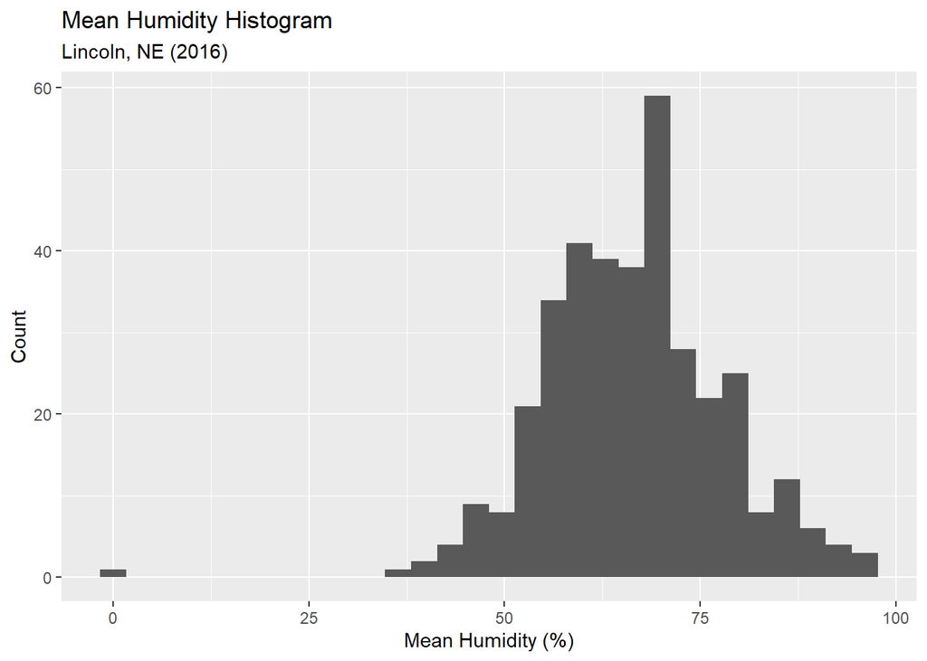

```r
# Histogram for average humidity
htdData %>%
    ggplot(aes(x=meanH)) +
    geom_histogram() +
    labs(title="Mean Humidity Histogram", subtitle="Lincoln, NE (2016)", x="Mean Humidity (%)", y="Count")
```

```r
htdData %>%
    filter((meanH < 25) | is.na(meanH))
```

```
## # A tibble: 2 x 6
##   CST       meanT meanD meanH date       month
##   <chr>     <int> <int> <int> <date>     <dbl>
## 1 2016-2-27    50    21     0 2016-02-27     2
## 2 2016-2-28    44    NA    NA 2016-02-28     2
```

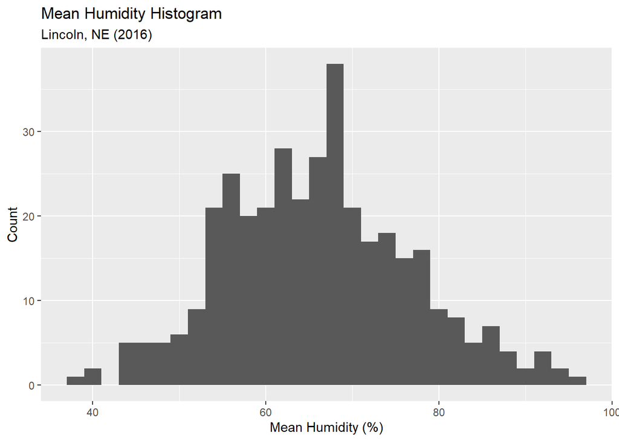

```r
htdData <- htdData %>%
    filter(!((meanH < 25) | is.na(meanH)))

# Updated Histogram for average humidity
htdData %>%
    ggplot(aes(x=meanH)) +
    geom_histogram() +
    labs(title="Mean Humidity Histogram", subtitle="Lincoln, NE (2016)", x="Mean Humidity (%)", y="Count")
```

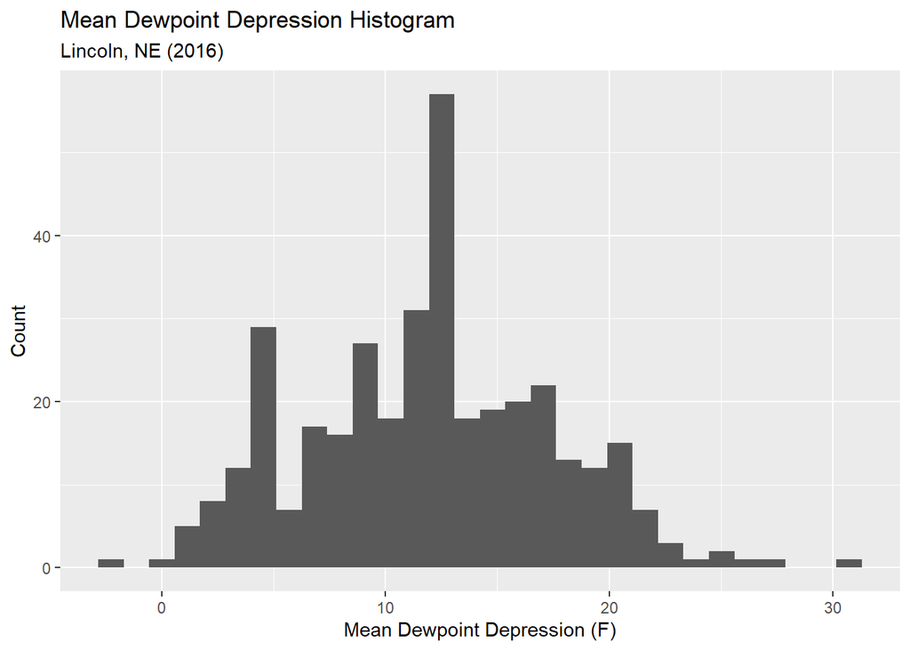

```r
# Histogram for dewpoint depression (T - D)
htdData %>%
    ggplot(aes(x=meanT-meanD)) +
    geom_histogram() +
    labs(title="Mean Dewpoint Depression Histogram", subtitle="Lincoln, NE (2016)",
         x="Mean Dewpoint Depression (F)", y="Count")
```

```r
htdData %>%
    filter(meanD >= meanT)
```

```
## # A tibble: 2 x 6
##   CST        meanT meanD meanH date       month
##   <chr>      <int> <int> <int> <date>     <dbl>
## 1 2016-1-7      30    30    96 2016-01-07     1
## 2 2016-11-27    37    39    85 2016-11-27    11
```

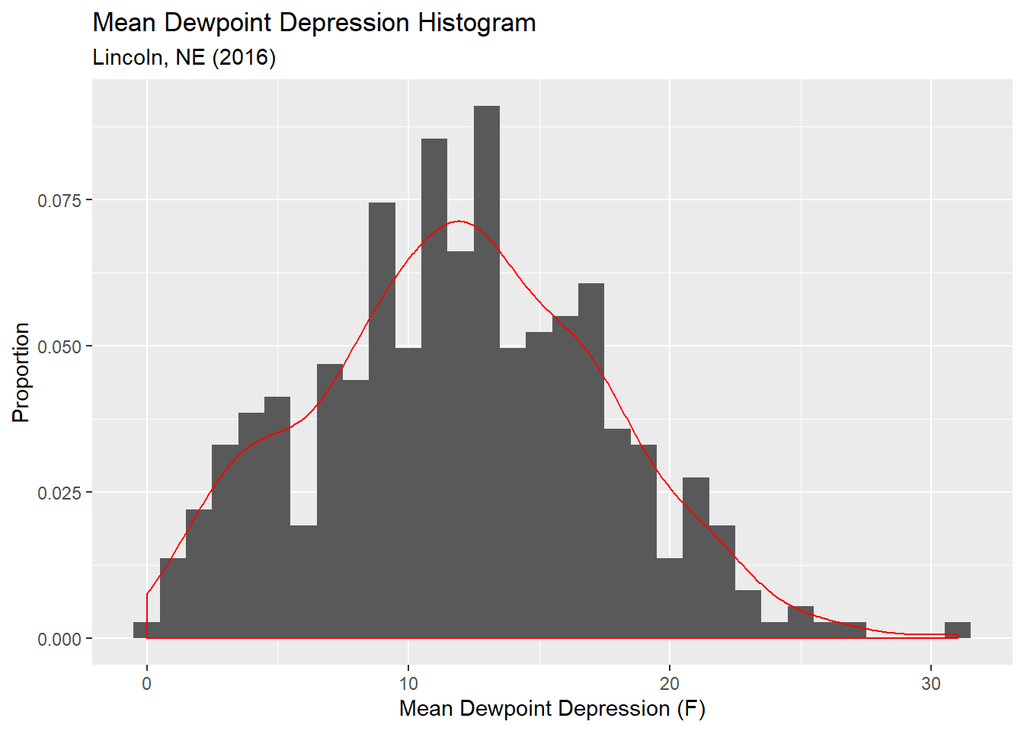

```r
htdData <- htdData %>%
    filter(meanT >= meanD)

# Updated Histogram for dewpoint depression (T - D)
htdData %>%
    ggplot(aes(x=meanT-meanD, y=..density..)) +
    geom_histogram(binwidth=1) +
    geom_density(color="red") +
    labs(title="Mean Dewpoint Depression Histogram", subtitle="Lincoln, NE (2016)",
         x="Mean Dewpoint Depression (F)", y="Proportion")
```

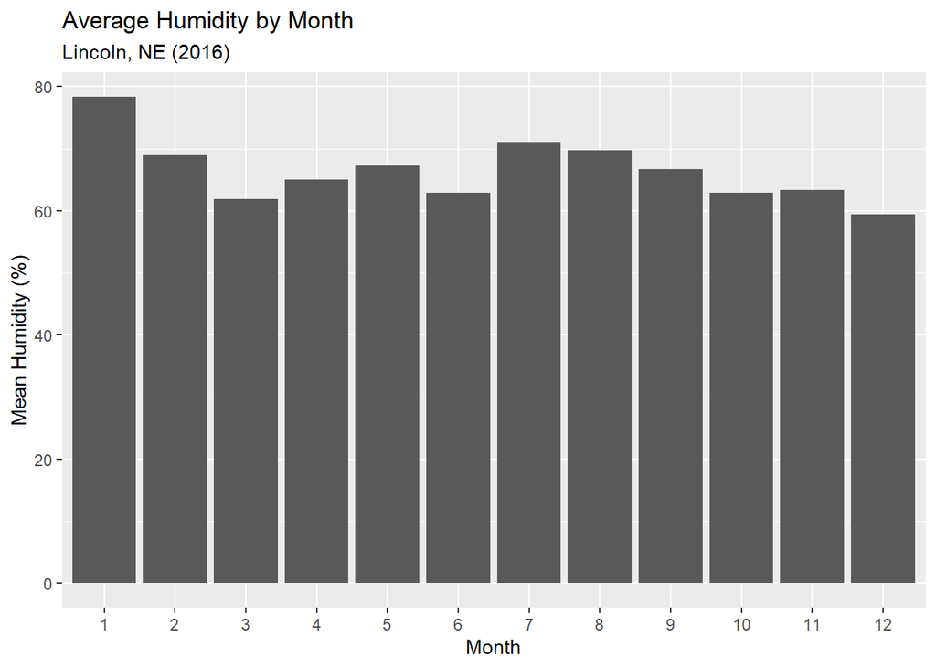

```r
# Average humidity by month
htdData %>%
    group_by(month) %>%
    summarize(meanH=mean(meanH, na.rm=TRUE)) %>%
    ggplot(aes(x=as.factor(month), y=meanH)) +
    geom_col() +
    labs(title="Average Humidity by Month", subtitle="Lincoln, NE (2016)", x="Month", y="Mean Humidity (%)")
```

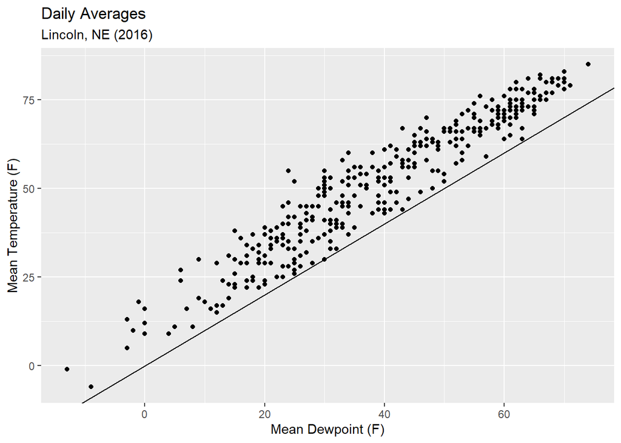

```r
# Relationship between temperature and dewpoint
htdData %>%
    ggplot(aes(x=meanD, y=meanT)) +
    geom_point() +
    geom_abline(slope=1, intercept=0) +
    labs(title="Daily Averages", subtitle="Lincoln, NE (2016)",
         x="Mean Dewpoint (F)", y="Mean Temperature (F)"
         )
```

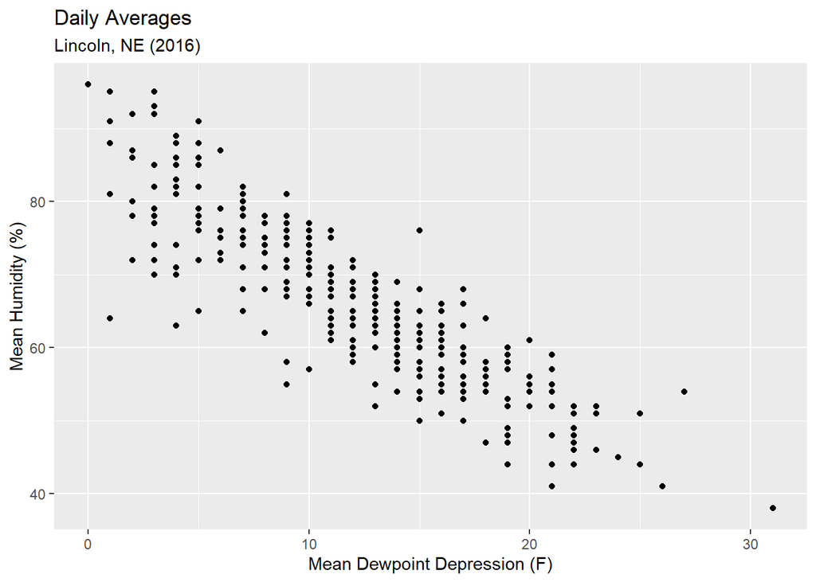

```r
# Relationship between dewpoint depression and humidity
htdData %>%
    mutate(dpD=meanT-meanD) %>%
    ggplot(aes(x=dpD, y=meanH)) +
    geom_point() +
    labs(title="Daily Averages", subtitle="Lincoln, NE (2016)",
         x="Mean Dewpoint Depression (F)", y="Mean Humidity (%)"
         )
```

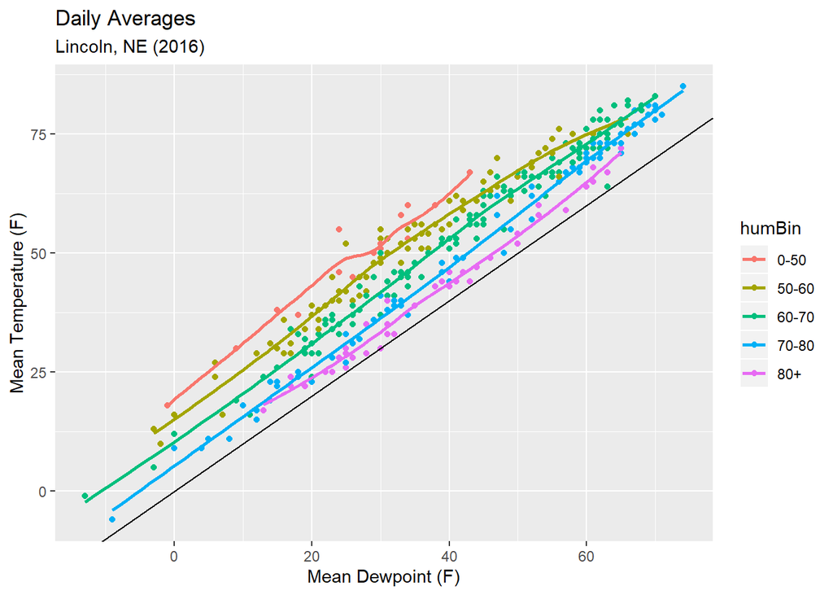

```r
# Relationship between temperature and dewpoint and humidity
humInts <- c(0, 50, 60, 70, 80)
humLabel <- sapply(1:(length(humInts)-1), FUN=function(x) { paste0(humInts[x], "-", humInts[x+1]) })
humLabel <- c(humLabel, paste0(humInts[length(humInts)], "+"))

htdData %>%
    mutate(humBin=factor(findInterval(meanH, humInts), levels=1:length(humInts), labels=humLabel)) %>%
    ggplot(aes(x=meanD, y=meanT, color=humBin)) +
    geom_point() +
    geom_smooth(se=FALSE) +
    geom_abline(slope=1, intercept=0) +
    labs(title="Daily Averages", subtitle="Lincoln, NE (2016)",
         x="Mean Dewpoint (F)", y="Mean Temperature (F)"
         )
```

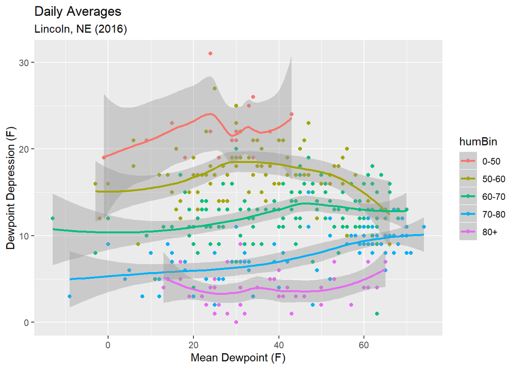

```r
# Expressed using dewpoint depression vs. dewpoint
htdData %>%
    mutate(humBin=factor(findInterval(meanH, humInts), levels=1:length(humInts), labels=humLabel)) %>%
    ggplot(aes(x=meanD, y=meanT-meanD, color=humBin)) +
    geom_point() +
    geom_smooth() +
    labs(title="Daily Averages", subtitle="Lincoln, NE (2016)",
         x="Mean Dewpoint (F)", y="Dewpoint Depression (F)"
         )
```

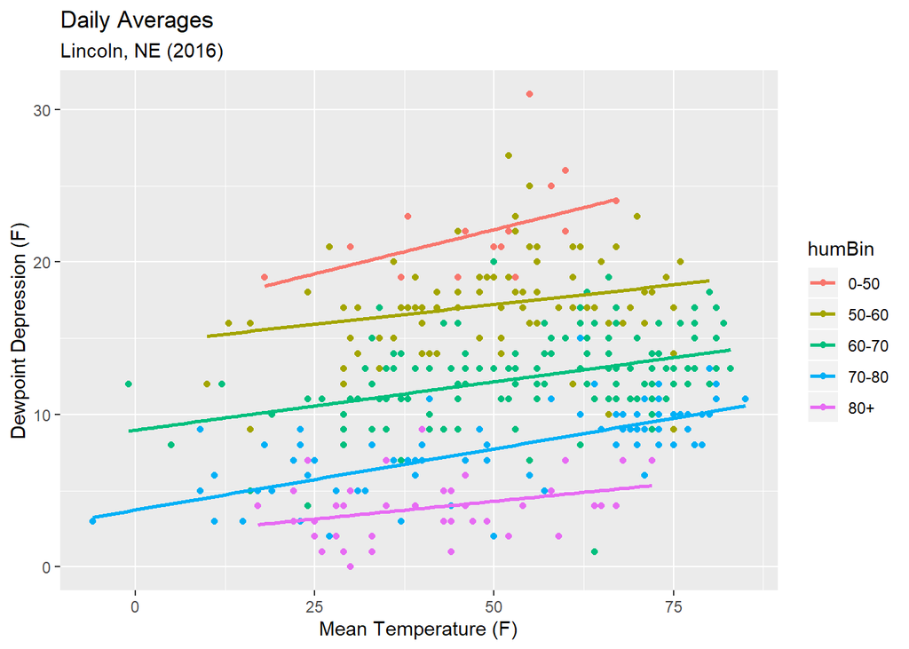

```r
# Expressed using dewpoint depression vs. temperature
htdData %>%
    mutate(humBin=factor(findInterval(meanH, humInts), levels=1:length(humInts), labels=humLabel)) %>%
    ggplot(aes(x=meanT, y=meanT-meanD, color=humBin)) +
    geom_point() +
    geom_smooth(se=FALSE, method="lm") +
    labs(title="Daily Averages", subtitle="Lincoln, NE (2016)",
         x="Mean Temperature (F)", y="Dewpoint Depression (F)"
         )
```

```r
# Linear regression for temperature, dewpoint, and humidity
htdReg <- htdData %>%
    mutate(dpD=meanT-meanD) %>%
    lm(meanH ~ meanT + dpD, data=.)
summary(htdReg)
```

```
##
## Call:
## lm(formula = meanH ~ meanT + dpD, data = .)
##
## Residuals:
##      Min       1Q   Median       3Q      Max
## -23.3569  -2.5472  -0.1894   2.7285  14.4934
##
## Coefficients:
##             Estimate Std. Error t value Pr(>|t|)
## (Intercept) 82.89890    0.83037  99.833  < 2e-16 ***
## meanT        0.09771    0.01403   6.965 1.57e-11 ***
## dpD         -1.79530    0.04811 -37.317  < 2e-16 ***
## ---
## Signif. codes:  0 '***' 0.001 '**' 0.01 '*' 0.05 '.' 0.1 ' ' 1
##
## Residual standard error: 4.869 on 360 degrees of freedom
## Multiple R-squared:  0.796,  Adjusted R-squared:  0.7949
## F-statistic: 702.4 on 2 and 360 DF,  p-value: < 2.2e-16
```

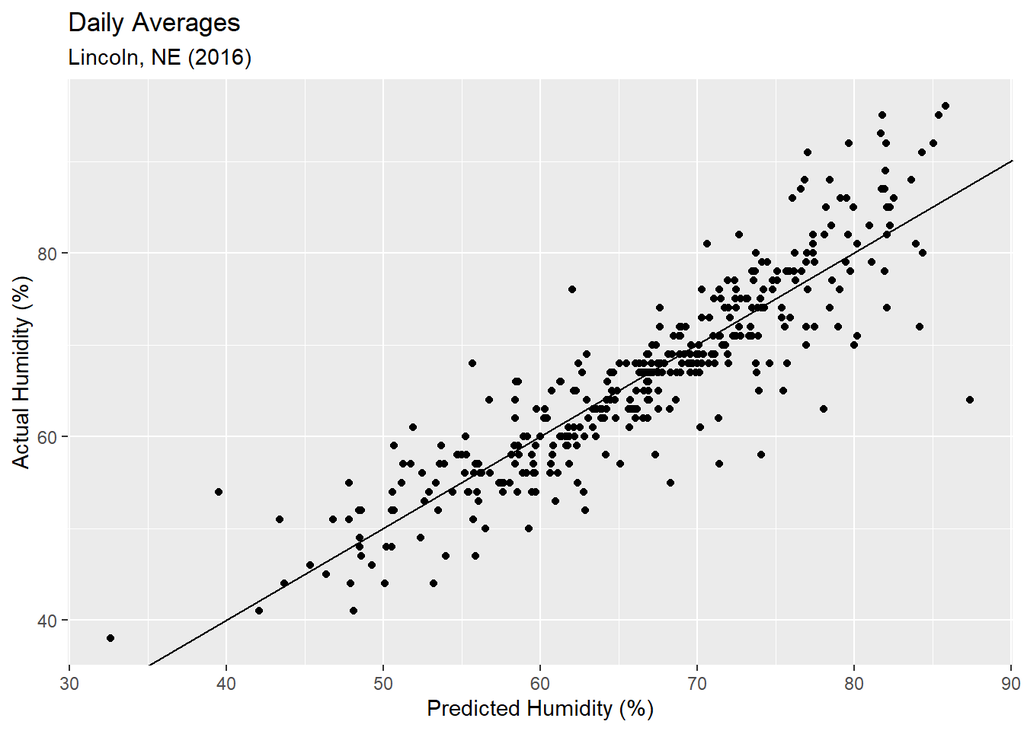

```r
htdData %>%
    mutate(dpD=meanT-meanD) %>%
    mutate(predH=predict(htdReg, newdata=.)) %>%
    ggplot(aes(x=predH, y=meanH)) +
    geom_point() +
    geom_abline(slope=1, intercept=0) +
    labs(title="Daily Averages", subtitle="Lincoln, NE (2016)",
         x="Predicted Humidity (%)", y="Actual Humidity (%)"
         )
```

#### *Example #11: Plotting Weather Data (Wind)*

Wind data (speed, gust, direction) are also available in the lincoln_weather dataset..

Example code includes:

```r
# Extract wind data
wdData <- lincoln_weather %>%
    select(CST, maxW=`Max Wind Speed [MPH]`, maxG=`Max Gust Speed [MPH]`, meanW=`Mean Wind Speed[MPH]`,
           dirW=`WindDir [Degrees]`
           ) %>%
    mutate(date=as.Date(CST))
str(wdData)
```

```
## Classes 'tbl_df', 'tbl' and 'data.frame':    366 obs. of  6 variables:
##  $ CST  : chr  "2016-1-1" "2016-1-2" "2016-1-3" "2016-1-4" ...
##  $ maxW : int  20 15 13 17 22 16 16 25 25 10 ...
##  $ maxG : int  23 18 14 23 28 21 21 32 28 12 ...
##  $ meanW: int  9 6 5 7 13 7 7 16 14 5 ...
##  $ dirW : int  280 312 330 155 178 167 7 338 340 268 ...
##  $ date : Date, format: "2016-01-01" "2016-01-02" ...
```

```r
# Manage missing data
wdData[!complete.cases(wdData), ]
```

```
## # A tibble: 6 x 6
##   CST         maxW  maxG meanW  dirW date
##   <chr>      <int> <int> <int> <int> <date>
## 1 2016-2-6      18    NA     5   241 2016-02-06
## 2 2016-2-28     36    45    18    NA 2016-02-28
## 3 2016-5-31     17    NA    11   319 2016-05-31
## 4 2016-6-18     NA    NA    NA    -1 2016-06-18
## 5 2016-6-19     NA    NA    NA    -1 2016-06-19
## 6 2016-12-19    17    NA     9   209 2016-12-19
```

```r
wdData <- wdData %>%
    filter(dirW != -1, !is.na(dirW)) %>%
    mutate(maxG=ifelse(is.na(maxG), maxW, maxG))
summary(wdData)
```

```
##      CST                 maxW             maxG            meanW
##  Length:363         Min.   :  8.00   Min.   : 10.00   Min.   : 0.00
##  Class :character   1st Qu.: 16.00   1st Qu.: 21.00   1st Qu.: 6.00
##  Mode  :character   Median : 21.00   Median : 26.00   Median : 8.00
##                     Mean   : 21.71   Mean   : 27.93   Mean   : 9.11
##                     3rd Qu.: 25.00   3rd Qu.: 33.00   3rd Qu.:11.00
##                     Max.   :131.00   Max.   :143.00   Max.   :27.00
##       dirW            date
##  Min.   :  1.0   Min.   :2016-01-01
##  1st Qu.:143.5   1st Qu.:2016-04-01
##  Median :193.0   Median :2016-07-03
##  Mean   :209.8   Mean   :2016-07-01
##  3rd Qu.:310.0   3rd Qu.:2016-10-01
##  Max.   :358.0   Max.   :2016-12-31
```

```r
# Manage very high wind data
wdData[wdData$maxG >= 60, ]
```

```
## # A tibble: 3 x 6
##   CST         maxW  maxG meanW  dirW date
##   <chr>      <int> <int> <int> <int> <date>
## 1 2016-3-23     45    61    25    20 2016-03-23
## 2 2016-6-17    131   143    20   170 2016-06-17
## 3 2016-12-25    51    64    19   139 2016-12-25
```

```r
wdData <- wdData %>%
    filter(maxG <= 80)
summary(wdData)
```

```
##      CST                 maxW           maxG           meanW
##  Length:362         Min.   : 8.0   Min.   :10.00   Min.   : 0.00
##  Class :character   1st Qu.:16.0   1st Qu.:21.00   1st Qu.: 6.00
##  Mode  :character   Median :21.0   Median :26.00   Median : 8.00
##                     Mean   :21.4   Mean   :27.61   Mean   : 9.08
##                     3rd Qu.:25.0   3rd Qu.:33.00   3rd Qu.:11.00
##                     Max.   :51.0   Max.   :64.00   Max.   :27.00
##       dirW            date
##  Min.   :  1.0   Min.   :2016-01-01
##  1st Qu.:143.2   1st Qu.:2016-04-01
##  Median :193.0   Median :2016-07-03
##  Mean   :209.9   Mean   :2016-07-01
##  3rd Qu.:310.0   3rd Qu.:2016-10-01
##  Max.   :358.0   Max.   :2016-12-31
```

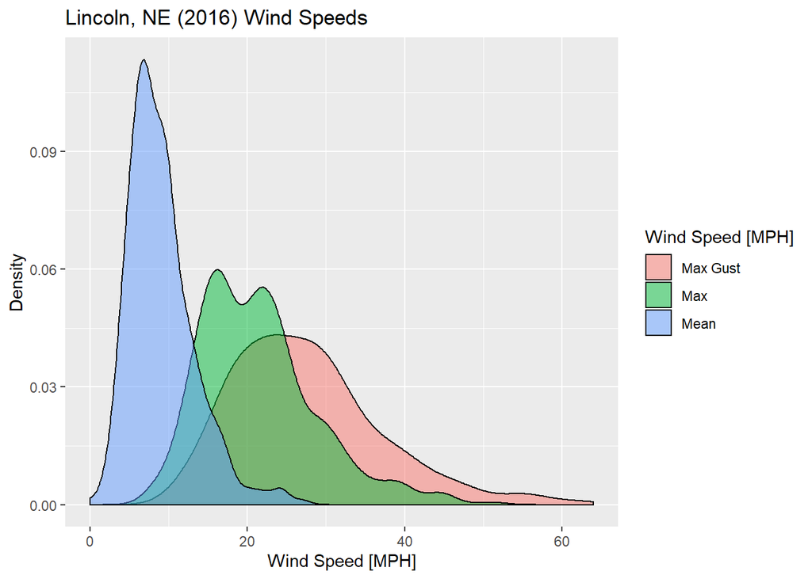

```r
# Density of wind speeds
wdData %>%
    select(date, meanW, maxW, maxG) %>%
    pivot_longer(-date) %>%
    ggplot(aes(x=value, fill=name)) +
    geom_density(alpha=0.5) +
    scale_fill_discrete(name="Wind Speed [MPH]", labels=c("Max Gust", "Max", "Mean")) +
    labs(title="Lincoln, NE (2016) Wind Speeds", y="Density", x="Wind Speed [MPH]")
```

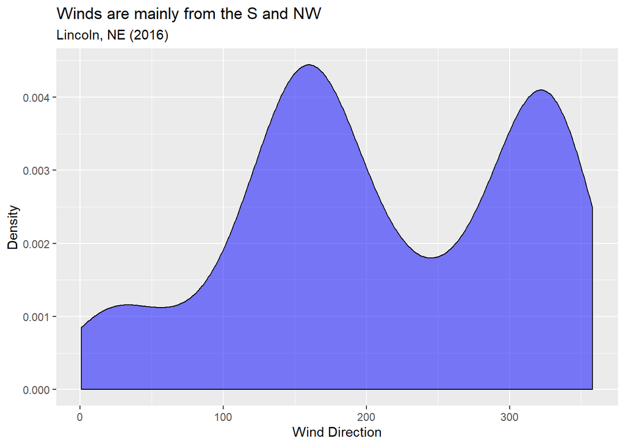

```r
# Density of wind direction
wdData %>%
    select(date, dirW) %>%
    ggplot(aes(x=dirW)) +
    geom_density(alpha=0.5, fill="blue") +
    labs(title="Winds are mainly from the S and NW", subtitle="Lincoln, NE (2016)",
         y="Density", x="Wind Direction"
         )
```

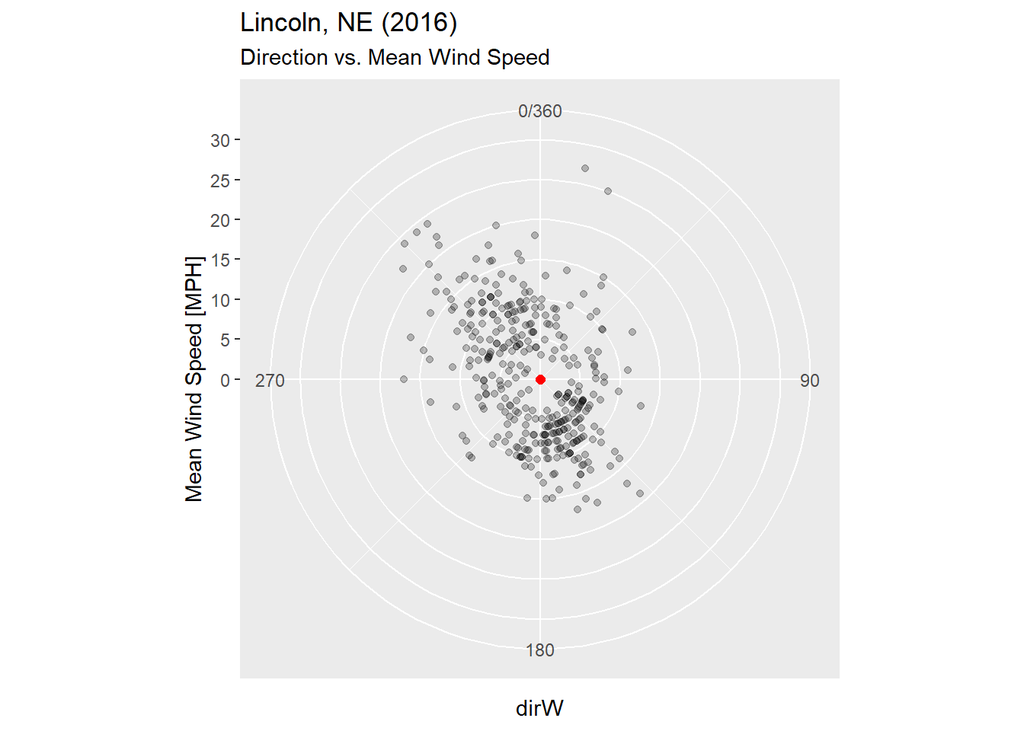

```r
# Wind speed and direction
wdData %>%
    ggplot(aes(x=meanW, y=dirW)) +
    geom_point(alpha=0.25) +
    coord_polar(theta="y") +
    labs(title="Lincoln, NE (2016)", subtitle="Direction vs. Mean Wind Speed", x="Mean Wind Speed [MPH]") +
    scale_y_continuous(limits=c(0, 360), breaks=c(0, 90, 180, 270, 360)) +
    scale_x_continuous(limits=c(0, 30), breaks=c(0, 5, 10, 15, 20, 25, 30)) +
    geom_point(aes(x=0, y=0), color="red", size=2)
```

```r
# Wind speed and direction as factors
windDirs <- c("N", "NE", "E", "SE", "S", "SW", "W", "NW")
windSpeeds <- c(0, 5, 10, 15)
windLabels <- sapply(1:(length(windSpeeds)-1), FUN=function(x){ paste0(windSpeeds[x], "-", windSpeeds[x+1]) })
windLabels <- c(windLabels, paste0(windSpeeds[length(windSpeeds)], "+"))
wdData <- wdData %>%
    mutate(wd=factor(floor(((dirW+22.5)/45) %% 8), levels=0:7, labels=windDirs),
           ws=factor(findInterval(meanW, windSpeeds), levels=length(windSpeeds):1, labels=rev(windLabels))
           )

# Summary of interaction between wind speed and wind direction
wdData %>%
    group_by(wd) %>%
    summarize(n=n(), avgMean=mean(meanW), avgMax=mean(maxW), avgGust=mean(maxG))
```

```
## # A tibble: 8 x 5
##   wd        n avgMean avgMax avgGust
##   <fct> <int>   <dbl>  <dbl>   <dbl>
## 1 N        51   10.1    21.4    27.7
## 2 NE       18    8.17   19.4    24.8
## 3 E        16    7.44   18.9    24.6
## 4 SE       69    8.01   19.6    25.5
## 5 S        73    8.89   20.6    26.8
## 6 SW       26    6.96   20.3    26.2
## 7 W        29    8.10   20.4    26.5
## 8 NW       80   11.1    25.4    32.2
```

```r
table(wdData$wd, wdData$ws)
```

```
##
##      15+ 10-15 5-10 0-5
##   N    8    14   25   4
##   NE   1     7    6   4
##   E    0     3   12   1
##   SE   3    15   42   9
##   S    5    23   43   2
##   SW   0     6   15   5
##   W    3     4   18   4
##   NW  17    31   28   4
```

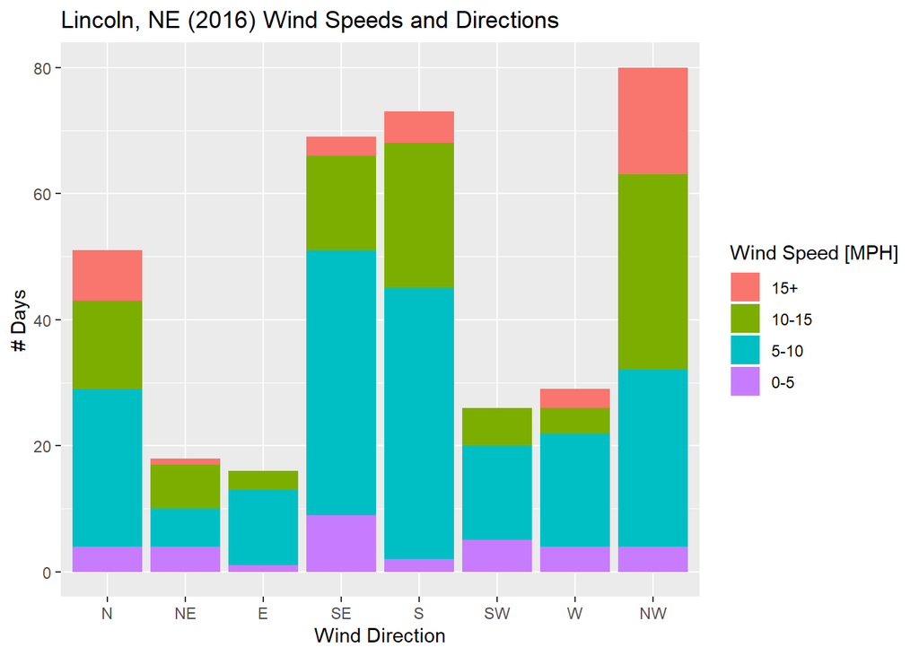

```r
# Graph of wind speed and wind direction
wdData %>%
    ggplot(aes(x=wd, fill=ws)) +
    geom_bar() +
    scale_fill_discrete(name="Wind Speed [MPH]") +
    labs(title="Lincoln, NE (2016) Wind Speeds and Directions", y="# Days", x="Wind Direction")
```

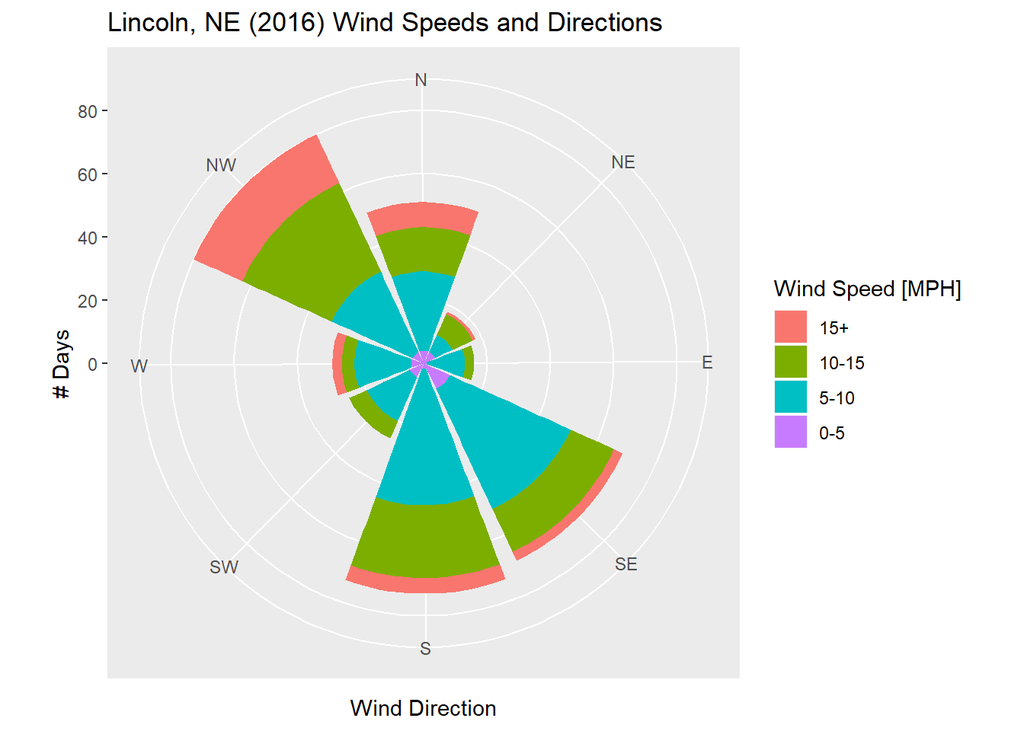

```r
# Graph of wind speed and wind direction (polar coordinates)
wdData %>%
    ggplot(aes(x=wd, fill=ws)) +
    geom_bar() +
    scale_fill_discrete(name="Wind Speed [MPH]") +
    labs(title="Lincoln, NE (2016) Wind Speeds and Directions", y="# Days", x="Wind Direction") +
    coord_polar(start=-0.4)
```

#### *Example #12: Archived granular weather Data (METAR)*

Iowa State has a great database of archived weather data, including the historical METAR data (meteorological aerodrome report) for a number of reporting stations.

METAR include information on visibility, wind, temperature, dew point, precipitation, clouds, barometric pressure, and other features that may impact safe aviation.

The data for station KLNK (Lincoln, NE airport) was saved as a CSV from Iowa State

Some processing is required before using the METAR data:

Example code includes:

```r
# Load METAR data
klnk <- readr::read_csv("./RInputFiles/metar_klnk_2016.txt", na=c("", "NA", "M"))
str(klnk, give.attr=FALSE)
```

```
## Classes 'spec_tbl_df', 'tbl_df', 'tbl' and 'data.frame': 10594 obs. of  29 variables:
##  $ station          : chr  "LNK" "LNK" "LNK" "LNK" ...
##  $ valid            : POSIXct, format: "2015-12-31 00:54:00" "2015-12-31 01:54:00" ...
##  $ tmpf             : num  27 26.1 27 27 27 ...
##  $ dwpf             : num  19.9 19.9 19.9 21 19.9 ...
##  $ relh             : num  74.5 77.3 74.5 78 74.5 ...
##  $ drct             : num  300 0 0 280 310 10 0 10 20 0 ...
##  $ sknt             : num  5 0 0 3 5 9 0 3 3 0 ...
##  $ p01i             : chr  "0.00" "0.00" "0.00" "0.00" ...
##  $ alti             : num  30.3 30.3 30.3 30.3 30.3 ...
##  $ mslp             : num  1028 1028 1028 1028 1029 ...
##  $ vsby             : num  10 10 10 10 10 10 10 10 10 10 ...
##  $ gust             : num  NA NA NA NA NA NA NA NA NA NA ...
##  $ skyc1            : chr  "OVC" "OVC" "OVC" "OVC" ...
##  $ skyc2            : chr  NA NA NA NA ...
##  $ skyc3            : chr  NA NA NA NA ...
##  $ skyc4            : logi  NA NA NA NA NA NA ...
##  $ skyl1            : num  2800 2700 2600 2700 2100 2700 2700 2700 2600 2600 ...
##  $ skyl2            : num  NA NA NA NA 2700 NA NA NA NA NA ...
##  $ skyl3            : num  NA NA NA NA NA NA NA NA NA NA ...
##  $ skyl4            : logi  NA NA NA NA NA NA ...
##  $ wxcodes          : chr  NA NA NA NA ...
##  $ ice_accretion_1hr: chr  NA NA NA NA ...
##  $ ice_accretion_3hr: chr  NA NA NA NA ...
##  $ ice_accretion_6hr: chr  NA NA NA NA ...
##  $ peak_wind_gust   : num  NA NA NA NA NA NA NA NA NA NA ...
##  $ peak_wind_drct   : num  NA NA NA NA NA NA NA NA NA NA ...
##  $ peak_wind_time   : POSIXct, format: NA NA ...
##  $ feel             : num  20.4 26.1 27 22.9 20.4 ...
##  $ metar            : chr  "KLNK 310054Z 30005KT 10SM OVC028 M03/M07 A3029 RMK AO2 SLP275 T10281067" "KLNK 310154Z 00000KT 10SM OVC027 M03/M07 A3030 RMK AO2 SLP277 T10331067" "KLNK 310254Z 00000KT 10SM OVC026 M03/M07 A3030 RMK AO2 SLP277 T10281067 51008" "KLNK 310354Z 28003KT 10SM OVC027 M03/M06 …
```

```r
# Filter to only data that ends with times ending in 54Z
metarKLNK <- klnk %>%
    filter(str_detect(metar, "54Z"))
dim(metarKLNK)
```

```
## [1] 8813   29
```

```r
# There should be 24*368=8832 records, so there are a handful (19) of missing METAR observations
minDate <- min(metarKLNK$valid)
expDate <- minDate + lubridate::hours(0:(24*368 - 1))

# Observations expected but not recorded
as.POSIXct(setdiff(expDate, metarKLNK$valid), origin="1970-01-01", tz="UTC")
```

```
##  [1] "2016-01-19 11:54:00 UTC" "2016-05-06 11:54:00 UTC"
##  [3] "2016-05-06 12:54:00 UTC" "2016-06-17 23:54:00 UTC"
##  [5] "2016-06-18 00:54:00 UTC" "2016-06-18 07:54:00 UTC"
##  [7] "2016-07-02 15:54:00 UTC" "2016-07-13 14:54:00 UTC"
##  [9] "2016-07-13 15:54:00 UTC" "2016-07-13 16:54:00 UTC"
## [11] "2016-07-13 17:54:00 UTC" "2016-07-30 13:54:00 UTC"
## [13] "2016-08-02 07:54:00 UTC" "2016-08-05 07:54:00 UTC"
## [15] "2016-08-29 21:54:00 UTC" "2016-09-15 16:54:00 UTC"
## [17] "2016-09-16 05:54:00 UTC" "2016-11-21 00:54:00 UTC"
## [19] "2016-12-03 08:54:00 UTC"
```

```r
# Observations recorded but not expected
setdiff(metarKLNK$valid, expDate)
```

```
## numeric(0)
```

```r
# Confirmation of uniqueness
length(unique(metarKLNK$valid)) == length(metarKLNK$valid)
```

```
## [1] TRUE
```

```r
# Extract wind speeds and direction
# The general wind format is dddssGssKT where ddd is the direction (VRB meaning variable), the main ss is the speed, and the Gss is the gust speed (optional and not always displayed)

mtxWind <- metarKLNK %>%
    pull(metar) %>%
    str_match(pattern="(\\d{3}|VRB)(\\d{2})(G\\d{2})?KT")
head(mtxWind)
```

```
##      [,1]      [,2]  [,3] [,4]
## [1,] "30005KT" "300" "05" NA
## [2,] "00000KT" "000" "00" NA
## [3,] "00000KT" "000" "00" NA
## [4,] "28003KT" "280" "03" NA
## [5,] "31005KT" "310" "05" NA
## [6,] "01009KT" "010" "09" NA
```

```r
table(mtxWind[, 2], useNA="ifany")
```

```
##
##  000  010  020  030  040  050  060  070  080  090  100  110  120  130  140  150
##  875  269  199  146  135  121  108   95   88   65  102  158  169  245  241  339
##  160  170  180  190  200  210  220  230  240  250  260  270  280  290  300  310
##  463  565  517  413  284  179  142   96   73   80  105   89  121  141  147  225
##  320  330  340  350  360  VRB <NA>
##  234  303  352  413  383  114   19
```

```r
table(mtxWind[, 3], useNA="ifany")
```

```
##
##   00   03   04   05   06   07   08   09   10   11   12   13   14   15   16   17
##  875  615  704  664  696  651  636  599  536  451  439  371  315  276  235  173
##   18   19   20   21   22   23   24   25   26   27   28   29   30   31   32   34
##  156  108   69   62   45   33   23   13   14    9   10    6    6    2    1    1
## <NA>
##   19
```

```r
table(mtxWind[, 4], useNA="ifany")
```

```
##
##  G14  G15  G16  G17  G18  G19  G20  G21  G22  G23  G24  G25  G26  G27  G28  G29
##    6   11   11   16   30   59   69   87   83  107  101   83   62   61   61   37
##  G30  G31  G32  G33  G34  G35  G36  G37  G38  G39  G40  G41  G42  G43  G45 <NA>
##   28   24   18   13   12   14    6    6   10   11    2    3    1    2    2 7777
```

```r
# Verify that winds not captured are in fact missing from the METAR
metarKLNK[which(is.na(mtxWind[, 2])), "metar"]
```

```
## # A tibble: 19 x 1
##    metar
##    <chr>
##  1 KLNK 291354Z 10SM CLR M01/M03 A2976 RMK AO2 SLP088 T10061028
##  2 KLNK 012154Z 10SM CLR 01/M08 A3018 RMK AO2 SLP234 T00061083
##  3 KLNK 201754Z 10SM CLR 06/M07 A3041 RMK AO2 SLP308 T00611067 10061 21039 58013
##  4 KLNK 221754Z 10SM CLR 16/03 A2955 RMK AO2 SLP000 T01610033 10161 20106 58006~
##  5 KLNK 221854Z 10SM CLR 17/03 A2954 RMK AO2 SLP000 T01670033 $
##  6 KLNK 050254Z 10SM CLR 14/03 A3004 RMK AO2 SLP169 T01390033 53007
##  7 KLNK 181754Z 10SM OVC075 21/04 A3023 RMK AO2 SLP234 T02110039 10217 20072 58~
##  8 KLNK 011454Z 21/10 A3008 RMK AO2 SLP178 T02110100 51011 $
##  9 KLNK 152254Z 10SM CLR 38/11 A2978 RMK AO2 SLP070 T03780106
## 10 KLNK 181954Z 10SM SCT045 31/20 A3017 RMK AO2 SLP205 T03060200
## 11 KLNK 261654Z 10SM CLR 29/18 A3014 RMK AO2 SLP192 T02890183 $
## 12 KLNK 261754Z 10SM CLR 31/18 A3012 RMK AO2 SLP188 T03060178 10306 20222
## 13 KLNK 271754Z 10SM CLR 33/18 A3015 RMK AO2 SLP198 T03330183 10333 20222 55001
## 14 KLNK 251754Z 10SM CLR 29/17 A3013 RMK AO2 SLP192 T02890167 10289 20194 58010
## 15 KLNK 261854Z 10SM CLR 30/18 A3006 RMK AO2 SLP166 T03000183
## 16 KLNK 211854Z 10SM CLR 27/10 A3007 RMK AO2 SLP174 T02670100
## 17 KLNK 201454Z 10SM CLR 24/21 A3008 RMK AO2 SLP178 T02390206 56004 $
## 18 KLNK 051854Z 10SM CLR 22/07 A3027 RMK AO2 SLP244 T02170067
## 19 KLNK 170754Z AUTO 10SM CLR 08/05 A2950 RMK AO2 SLP984 T00830050
```

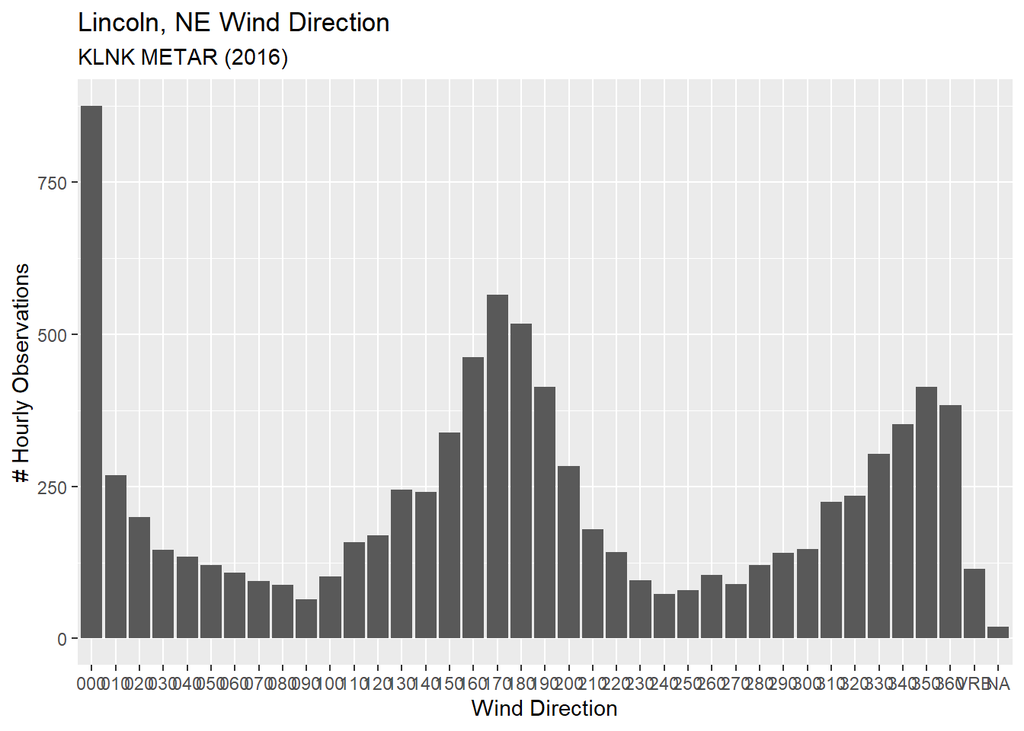

```r
metarKLNK <- metarKLNK %>%
    mutate(dirW=mtxWind[, 2],
           spdW=as.numeric(mtxWind[, 3]),
           gustW=as.numeric(str_replace(mtxWind[, 4], "G", ""))
           )

# Plot for the wind direction
metarKLNK %>%
    ggplot(aes(x=dirW)) +
    geom_bar() +
    labs(title="Lincoln, NE Wind Direction", subtitle="KLNK METAR (2016)",
         y="# Hourly Observations", x="Wind Direction"
         )
```

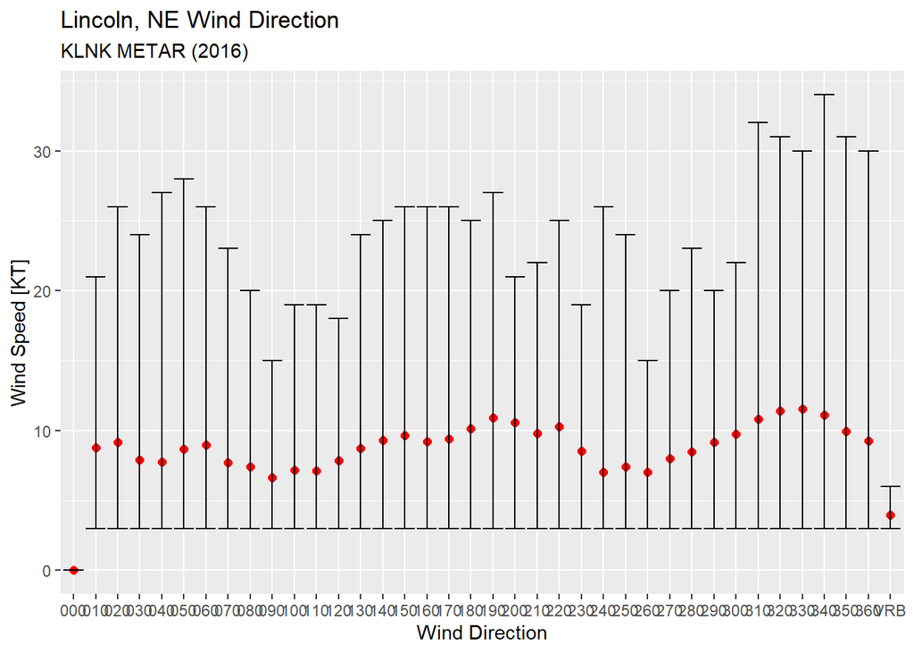

```r
# Plot for the minimum, average, and maximum wind speed by wind direction
# Wind direction 000 is reserved for 0 KT wind, while VRB is reserved for 3-6 KT variable winds
metarKLNK %>%
    filter(!is.na(dirW)) %>%
    group_by(dirW) %>%
    summarize(minWind=min(spdW), meanWind=mean(spdW), maxWind=max(spdW)) %>%
    ggplot(aes(x=dirW)) +
    geom_point(aes(y=meanWind), color="red", size=2) +
    geom_errorbar(aes(ymin=minWind, ymax=maxWind)) +
    labs(title="Lincoln, NE Wind Direction", subtitle="KLNK METAR (2016)",
         y="Wind Speed [KT]", x="Wind Direction"
         )
```

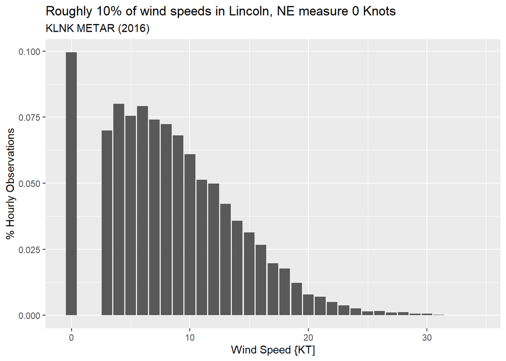

```r
# Plot for the wind speed
# Roughly 10% of the time, there is no wind in Lincoln
metarKLNK %>%
    ggplot(aes(x=spdW)) +
    geom_bar(aes(y=..count../sum(..count..))) +
    labs(title="Roughly 10% of wind speeds in Lincoln, NE measure 0 Knots", subtitle="KLNK METAR (2016)",
         y="% Hourly Observations", x="Wind Speed {KT]"
         )
```

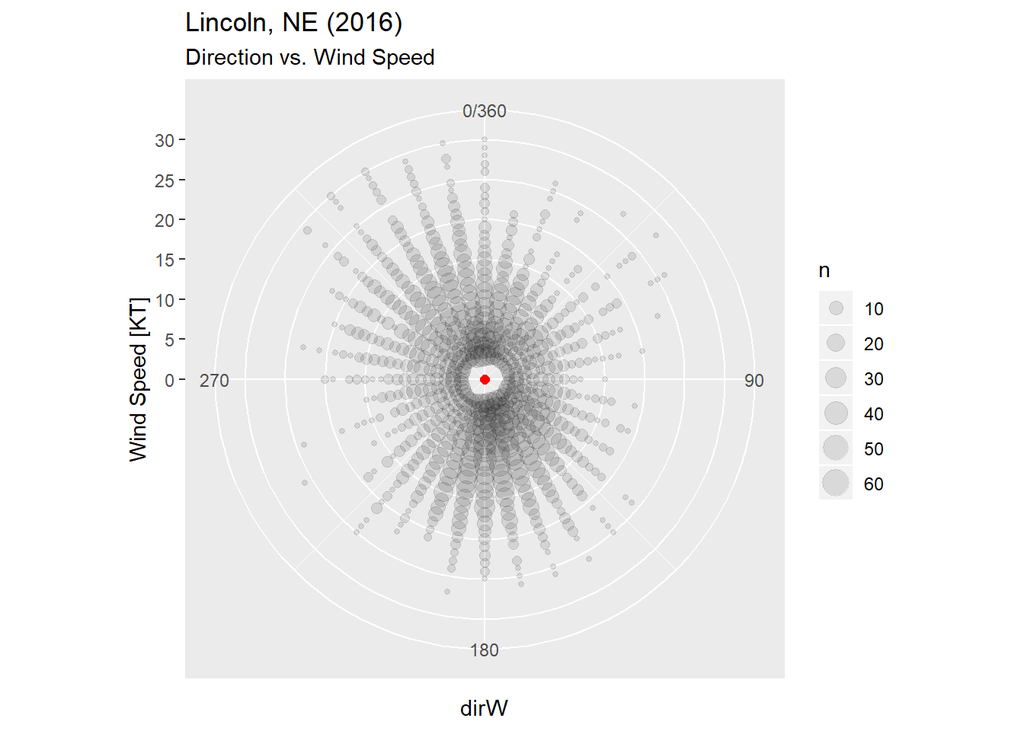

```r
metarKLNK %>%
    filter(!is.na(dirW), dirW != "VRB", dirW != "000") %>%
    mutate(dirW=as.numeric(dirW)) %>%
    group_by(dirW, spdW) %>%
    summarize(n=n()) %>%
    ggplot(aes(x=spdW, y=dirW)) +
    geom_point(alpha=0.1, aes(size=n)) +
    coord_polar(theta="y") +
    labs(title="Lincoln, NE (2016)", subtitle="Direction vs. Wind Speed", x="Wind Speed [KT]") +
    scale_y_continuous(limits=c(0, 360), breaks=c(0, 90, 180, 270, 360)) +
    scale_x_continuous(limits=c(0, 30), breaks=c(0, 5, 10, 15, 20, 25, 30)) +
    geom_point(aes(x=0, y=0), color="red", size=2)
```

#### *Example #13: Extracting Key Elements from METAR*

A properly formatted METAR includes the following information in order, though with variable amounts of other information in between.

dddd54Z ddddd[Gdd]KT dSM [M]dd/[M]dd Adddd RMK SLPddd Tdddddddd

- dddd54Z is the two-digit date and four-digit Zulu time (KLNK METAR are taken at 54 minutes past the hour)
- ddddd[Gdd]KT is the three-digit wind direction (can be VRB), two digit wind speed in knots, and sometimes the two digit maximum gust in knots
- dSM is the visibility in statute miles. This is somewhat tricky in that d can be any of 0-10 but can also be 1/4, 1/2, 3/4, 1 1/4, 1 1/2, 1 3/4, 2 1/2
- [M]dd/[M]dd is the temperature in celsius and dewpoint in celsius. M means negative
- Adddd is the four-digit altimeter reading
- RMK notes that the remarks are beginning
- SLPddd notes the three-digit sea-level pressure
- Tdddddddd notes the four digit temperature in Celsius and the four digit dewpoint in celsius. If it begins with 1 it is negative. The fourth digit is the decimal. It will always be a Celsius reading that best corresponds to integer degrees of Fahrenheit

Example code includes:

```r
metAll <- metarKLNK %>%
    pull(metar)

# Create a search string for METAR
valMet <- "54Z.*?(VRB|\\d{3})(\\d{2})(G\\d{2})?KT(.*?)(\\d{1,2}SM).*?\\s(M?\\d{2})/(M?\\d{2}).*?(A\\d{4}).*?RMK.*?(SLP\\d{3}).*?(T\\d{8})"

# Find the number of matching elements
str_detect(metAll, pattern=valMet) %>% table()
```

```
## .
## FALSE  TRUE
##    23  8790
```

```r
# The strings that do not match have errors in the raw data (typically, missing wind speed)
metAll[!str_detect(metAll, pattern=valMet)]
```

```
##  [1] "KLNK 291354Z 10SM CLR M01/M03 A2976 RMK AO2 SLP088 T10061028"
##  [2] "KLNK 012154Z 10SM CLR 01/M08 A3018 RMK AO2 SLP234 T00061083"
##  [3] "KLNK 201754Z 10SM CLR 06/M07 A3041 RMK AO2 SLP308 T00611067 10061 21039 58013"
##  [4] "KLNK 221654Z 19007KT CLR 15/03 A2956 RMK AO2 SLP006 T01500033 $"
##  [5] "KLNK 221754Z 10SM CLR 16/03 A2955 RMK AO2 SLP000 T01610033 10161 20106 58006 $"
##  [6] "KLNK 221854Z 10SM CLR 17/03 A2954 RMK AO2 SLP000 T01670033 $"
##  [7] "KLNK 050254Z 10SM CLR 14/03 A3004 RMK AO2 SLP169 T01390033 53007"
##  [8] "KLNK 181754Z 10SM OVC075 21/04 A3023 RMK AO2 SLP234 T02110039 10217 20072 58011"
##  [9] "KLNK 011454Z 21/10 A3008 RMK AO2 SLP178 T02110100 51011 $"
## [10] "KLNK 011554Z 32007KT CLR 22/09 A3008 RMK AO2 SLP179 T02170089 $"
## [11] "KLNK 152254Z 10SM CLR 38/11 A2978 RMK AO2 SLP070 T03780106"
## [12] "KLNK 181954Z 10SM SCT045 31/20 A3017 RMK AO2 SLP205 T03060200"
## [13] "KLNK 261554Z 05006KT 27/18 A3013 RMK AO2 SLP190 T02670178 RVRNO $"
## [14] "KLNK 261654Z 10SM CLR 29/18 A3014 RMK AO2 SLP192 T02890183 $"
## [15] "KLNK 261754Z 10SM CLR 31/18 A3012 RMK AO2 SLP188 T03060178 10306 20222"
## [16] "KLNK 271754Z 10SM CLR 33/18 A3015 RMK AO2 SLP198 T03330183 10333 20222 55001"
## [17] "KLNK 251754Z 10SM CLR 29/17 A3013 RMK AO2 SLP192 T02890167 10289 20194 58010"
## [18] "KLNK 261854Z 10SM CLR 30/18 A3006 RMK AO2 SLP166 T03000183"
## [19] "KLNK 211854Z 10SM CLR 27/10 A3007 RMK AO2 SLP174 T02670100"
## [20] "KLNK 201454Z 10SM CLR 24/21 A3008 RMK AO2 SLP178 T02390206 56004 $"
## [21] "KLNK 201554Z 15014G19KT CLR 27/22 A3007 RMK AO2 SLP174 T02670217 $"
## [22] "KLNK 051854Z 10SM CLR 22/07 A3027 RMK AO2 SLP244 T02170067"
## [23] "KLNK 170754Z AUTO 10SM CLR 08/05 A2950 RMK AO2 SLP984 T00830050"
```

```r
# A matrix of string matches can be obtained
mtxParse <- str_match(metAll, pattern=valMet)
head(mtxParse)
```

```
##      [,1]
## [1,] "54Z 30005KT 10SM OVC028 M03/M07 A3029 RMK AO2 SLP275 T10281067"
## [2,] "54Z 00000KT 10SM OVC027 M03/M07 A3030 RMK AO2 SLP277 T10331067"
## [3,] "54Z 00000KT 10SM OVC026 M03/M07 A3030 RMK AO2 SLP277 T10281067"
## [4,] "54Z 28003KT 10SM OVC027 M03/M06 A3031 RMK AO2 SLP281 T10281061"
## [5,] "54Z 31005KT 10SM SCT021 OVC027 M03/M07 A3033 RMK AO2 SLP286 T10281067"
## [6,] "54Z AUTO 01009KT 10SM OVC027 M06/M10 A3033 RMK AO2 SLP289 T10611100"
##      [,2]  [,3] [,4] [,5] [,6]   [,7]  [,8]  [,9]    [,10]    [,11]
## [1,] "300" "05" NA   " "  "10SM" "M03" "M07" "A3029" "SLP275" "T10281067"
## [2,] "000" "00" NA   " "  "10SM" "M03" "M07" "A3030" "SLP277" "T10331067"
## [3,] "000" "00" NA   " "  "10SM" "M03" "M07" "A3030" "SLP277" "T10281067"
## [4,] "280" "03" NA   " "  "10SM" "M03" "M06" "A3031" "SLP281" "T10281061"
## [5,] "310" "05" NA   " "  "10SM" "M03" "M07" "A3033" "SLP286" "T10281067"
## [6,] "010" "09" NA   " "  "10SM" "M06" "M10" "A3033" "SLP289" "T10611100"
```

```r
# Create a data frame
dfParse <- data.frame(mtxParse, stringsAsFactors=FALSE)
names(dfParse) <- c("METAR", "WindDir", "WindSpeed", "WindGust", "Dummy", "Visibility",
                    "TempC", "DewC", "Altimeter", "SLP", "FahrC"
                    )

# Convert to numeric where appropriate
dfParse <- dfParse %>%
    mutate(WindSpeed = as.integer(WindSpeed),
           WindGust = as.numeric(WindGust),
           Visibility = as.numeric(str_replace(Visibility, "SM", "")),
           TempC = as.integer(str_replace(TempC, "M", "-")),
           DewC = as.integer(str_replace(DewC, "M", "-")),
           Altimeter = as.integer(str_replace(Altimeter, "A", "")),
           SLP = as.integer(str_replace(SLP, "SLP", "")),
           TempF = 32 + 1.8 * as.integer(str_replace(str_sub(FahrC, 2, 5), pattern="^1", "-"))/10,
           DewF = 32 + 1.8 * as.integer(str_replace(str_sub(FahrC, 6, 9), pattern="^1", "-"))/10
           )
# Investigate the data
set.seed(2003211416)
str(dfParse)
```

```
## 'data.frame':    8813 obs. of  13 variables:
##  $ METAR     : chr  "54Z 30005KT 10SM OVC028 M03/M07 A3029 RMK AO2 SLP275 T10281067" "54Z 00000KT 10SM OVC027 M03/M07 A3030 RMK AO2 SLP277 T10331067" "54Z 00000KT 10SM OVC026 M03/M07 A3030 RMK AO2 SLP277 T10281067" "54Z 28003KT 10SM OVC027 M03/M06 A3031 RMK AO2 SLP281 T10281061" ...
##  $ WindDir   : chr  "300" "000" "000" "280" ...
##  $ WindSpeed : int  5 0 0 3 5 9 0 3 0 0 ...
##  $ WindGust  : num  NA NA NA NA NA NA NA NA NA NA ...
##  $ Dummy     : chr  " " " " " " " " ...
##  $ Visibility: num  10 10 10 10 10 10 10 10 10 10 ...
##  $ TempC     : int  -3 -3 -3 -3 -3 -6 -7 -8 -10 -9 ...
##  $ DewC      : int  -7 -7 -7 -6 -7 -10 -11 -11 -12 -12 ...
##  $ Altimeter : int  3029 3030 3030 3031 3033 3033 3034 3034 3034 3035 ...
##  $ SLP       : int  275 277 277 281 286 289 290 291 295 295 ...
##  $ FahrC     : chr  "T10281067" "T10331067" "T10281067" "T10281061" ...
##  $ TempF     : num  27 26.1 27 27 27 ...
##  $ DewF      : num  19.9 19.9 19.9 21 19.9 ...
```

```r
head(dfParse)
```

```
##                                                                   METAR WindDir
## 1        54Z 30005KT 10SM OVC028 M03/M07 A3029 RMK AO2 SLP275 T10281067     300
## 2        54Z 00000KT 10SM OVC027 M03/M07 A3030 RMK AO2 SLP277 T10331067     000
## 3        54Z 00000KT 10SM OVC026 M03/M07 A3030 RMK AO2 SLP277 T10281067     000
## 4        54Z 28003KT 10SM OVC027 M03/M06 A3031 RMK AO2 SLP281 T10281061     280
## 5 54Z 31005KT 10SM SCT021 OVC027 M03/M07 A3033 RMK AO2 SLP286 T10281067     310
## 6   54Z AUTO 01009KT 10SM OVC027 M06/M10 A3033 RMK AO2 SLP289 T10611100     010
##   WindSpeed WindGust Dummy Visibility TempC DewC Altimeter SLP     FahrC TempF
## 1         5       NA               10    -3   -7      3029 275 T10281067 26.96
## 2         0       NA               10    -3   -7      3030 277 T10331067 26.06
## 3         0       NA               10    -3   -7      3030 277 T10281067 26.96
## 4         3       NA               10    -3   -6      3031 281 T10281061 26.96
## 5         5       NA               10    -3   -7      3033 286 T10281067 26.96
## 6         9       NA               10    -6  -10      3033 289 T10611100 21.02
##    DewF
## 1 19.94
## 2 19.94
## 3 19.94
## 4 21.02
## 5 19.94
## 6 14.00
```

```r
tail(dfParse)
```

```
##                                                                     METAR
## 8808        54Z 16006KT 10SM OVC095 02/M04 A2993 RMK AO2 SLP147 T00221044
## 8809 54Z VRB04KT 10SM BKN090 OVC110 04/M04 A2990 RMK AO2 SLP139 T00391044
## 8810        54Z 13007KT 10SM BKN110 04/M07 A2989 RMK AO2 SLP134 T00441067
## 8811        54Z 11007KT 10SM OVC090 04/M07 A2988 RMK AO2 SLP130 T00391072
## 8812        54Z 10010KT 10SM OVC075 03/M05 A2986 RMK AO2 SLP125 T00331050
## 8813 54Z 10010KT 10SM FEW045 OVC070 03/M06 A2986 RMK AO2 SLP123 T00281056
##      WindDir WindSpeed WindGust Dummy Visibility TempC DewC Altimeter SLP
## 8808     160         6       NA               10     2   -4      2993 147
## 8809     VRB         4       NA               10     4   -4      2990 139
## 8810     130         7       NA               10     4   -7      2989 134
## 8811     110         7       NA               10     4   -7      2988 130
## 8812     100        10       NA               10     3   -5      2986 125
## 8813     100        10       NA               10     3   -6      2986 123
##          FahrC TempF  DewF
## 8808 T00221044 35.96 24.08
## 8809 T00391044 39.02 24.08
## 8810 T00441067 39.92 19.94
## 8811 T00391072 39.02 19.04
## 8812 T00331050 37.94 23.00
## 8813 T00281056 37.04 21.92
```

```r
dfParse %>%
    sample_n(20)
```

```
##                                                                                       METAR
## 1                            54Z AUTO 36007KT 10SM CLR 21/15 A2995 RMK AO2 SLP130 T02060150
## 2                              54Z 21013G20KT 10SM CLR 31/04 A2988 RMK AO2 SLP108 T03060044
## 3                            54Z 34011KT 10SM SCT120 M07/M13 A3025 RMK AO2 SLP259 T10721133
## 4                            54Z AUTO 24009KT 10SM CLR 13/08 A2961 RMK AO2 SLP018 T01330078
## 5                               54Z 31006KT 10SM CLR M07/M19 A3044 RMK AO2 SLP329 T10671189
## 6                                 54Z 04007KT 10SM CLR 26/14 A3010 RMK AO2 SLP179 T02560139
## 7  54Z 17017G24KT 10SM BKN038 BKN045 31/22 A2983 RMK AO2 PK WND 16028/1940 SLP090 T03110222
## 8                               54Z 16007KT 10SM CLR M01/M04 A3002 RMK AO2 SLP182 T10061044
## 9                                 54Z 31009KT 10SM CLR 13/09 A3021 RMK AO2 SLP226 T01280089
## 10            54Z 11010KT 10SM -RA FEW065 BKN110 16/16 A2990 RMK AO2 SLP116 P0000 T01610156
## 11                        54Z AUTO 14005KT 10SM OVC060 19/18 A3013 RMK AO2 SLP199 T01940178
## 12                                54Z 11006KT 10SM CLR 20/04 A3012 RMK AO2 SLP197 T02000044
## 13                               54Z 22004KT 10SM CLR 03/M04 A3042 RMK AO2 SLP311 T00281039
## 14                            54Z AUTO 35003KT 8SM CLR 09/08 A3011 RMK AO2 SLP194 T00940083
```

[output cut: 48 more lines]

```r
# Check for NA values
colSums(is.na(dfParse))
```

```
##      METAR    WindDir  WindSpeed   WindGust      Dummy Visibility      TempC
##         23         23         23       8813         23         23         23
##       DewC  Altimeter        SLP      FahrC      TempF       DewF
##         23         23         23         23         23         23
```

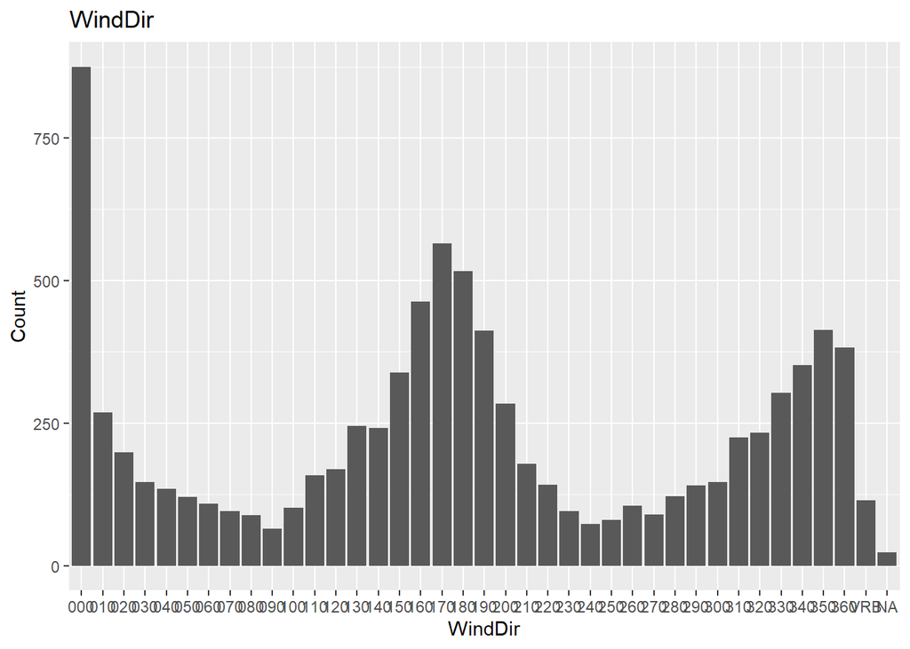

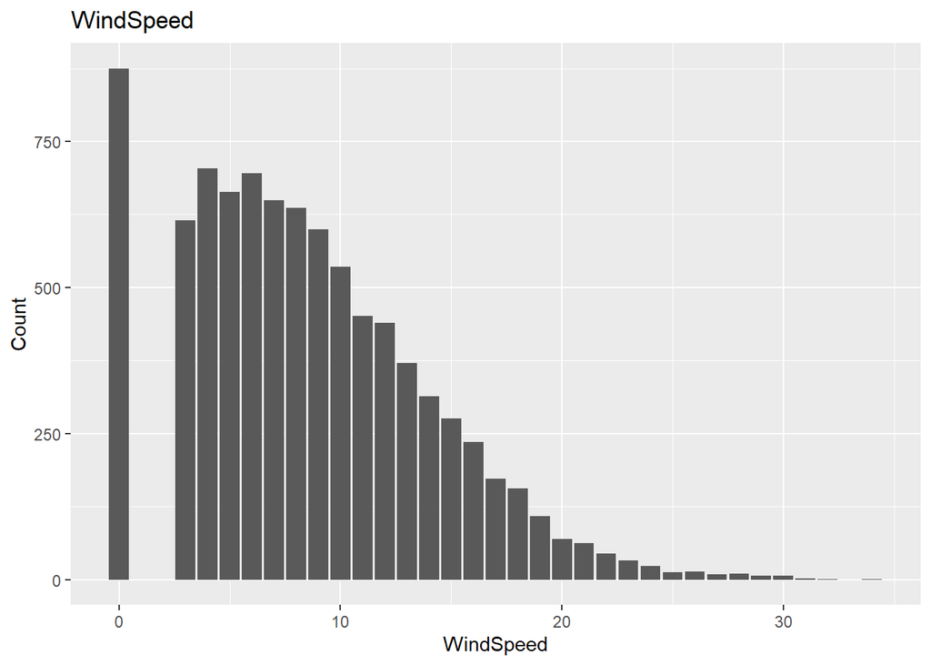

[figure not shown]

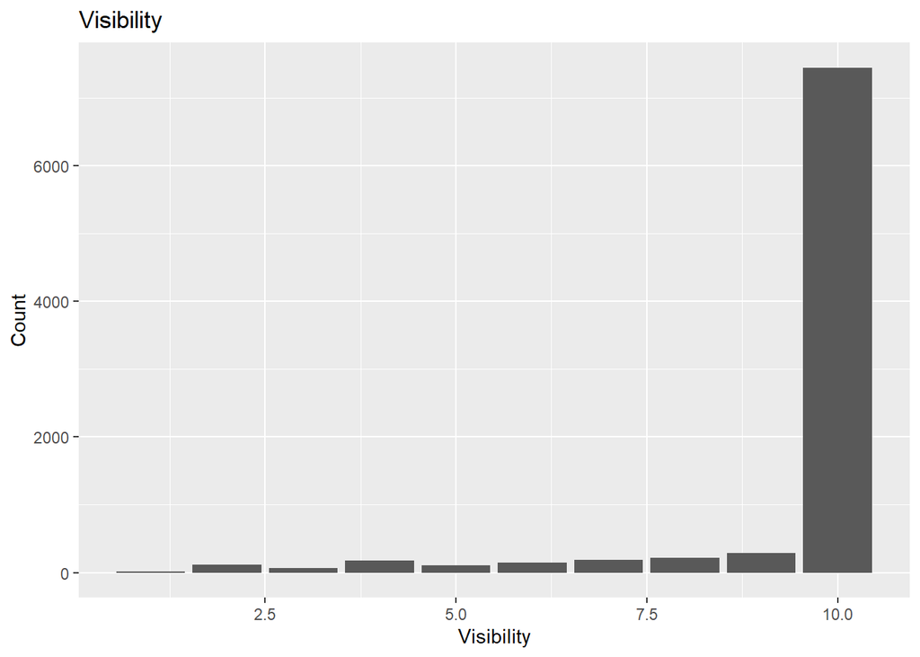

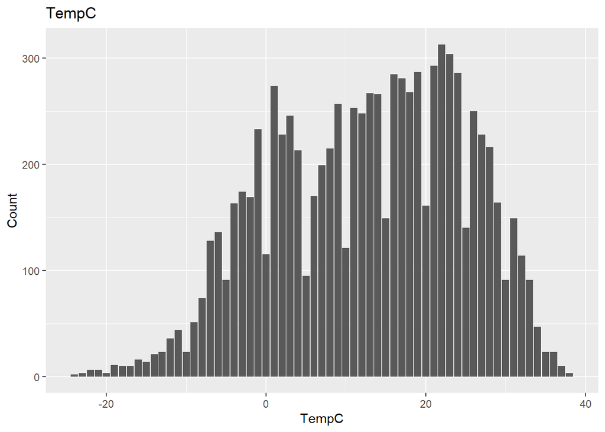

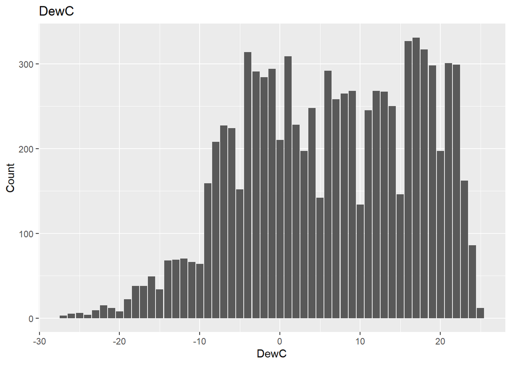

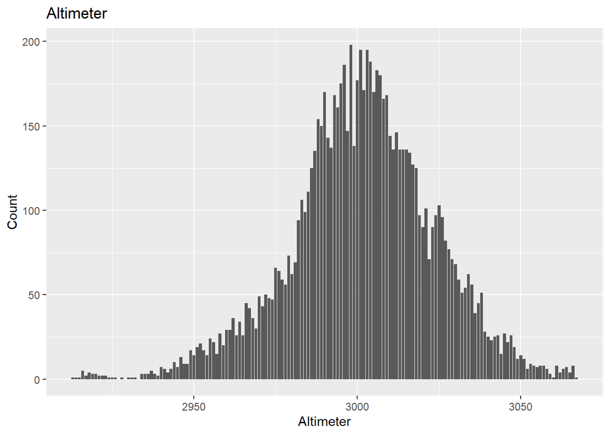

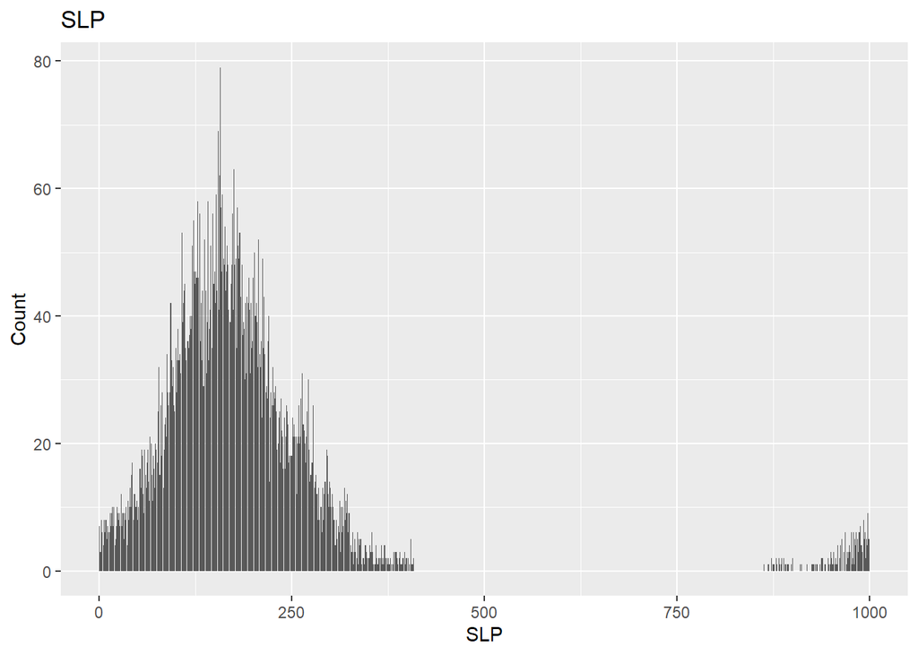

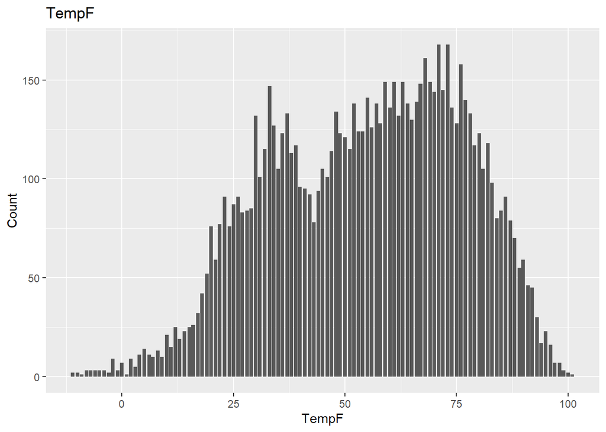

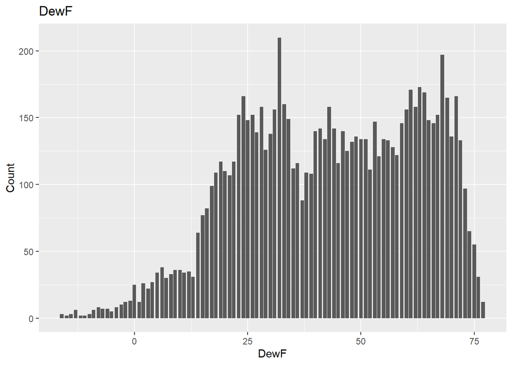

```r
# Plot of counts by key metric
keyMetric <- c("WindDir", "WindSpeed", "WindGust", "Visibility", "TempC",
               "DewC", "Altimeter", "SLP", "TempF", "DewF"
               )

for (x in keyMetric) {
    p <- dfParse %>%
        group_by_at(vars(all_of(x))) %>%
        summarize(n=n()) %>%
        ggplot(aes_string(x=x, y="n")) +
        geom_col() +
        labs(title=x, y="Count")
    print(p)
}
```

```r
# There are three obvious issues
# Visibility is not correctly picked up when there is a / such as 1/2 SM
# Wind gusts are never picked up
# Sea Level Pressure is missing a digit

# Correct for visibility
# Areas that have \\d \\d/\\dSM
sm1 <- which(str_detect(metAll, pattern=" \\d/\\dSM"))
sm2 <- which(str_detect(metAll, pattern=" \\d \\d/\\dSM"))

valSM1 <- str_match(metAll, pattern="\\d/\\dSM")[sm1]
valSM1 <- str_replace(valSM1, "SM", "")
valSM1 <- as.integer(str_sub(valSM1, 1, 1)) / as.integer(str_sub(valSM1, 3, 3))

valSM2 <- str_match(metAll, pattern=" \\d \\d/\\dSM")[sm2]
valSM2 <- as.integer(str_sub(valSM2, 2, 2))

dfParse[sm1, "Visibility"] <- valSM1
dfParse[sm2, "Visibility"] <- dfParse[sm2, "Visibility"] + valSM2

dfParse %>%
    count(Visibility)
```

```
## # A tibble: 18 x 2
##    Visibility     n
##         <dbl> <int>
##  1       0.25    20
##  2       0.5     16
##  3       0.75    15
##  4       1       19
##  5       1.25    13
##  6       1.5     17
##  7       1.75    21
##  8       2       50
##  9       2.5     38
## 10       3       70
## 11       4      108
## 12       5      108
## 13       6      146
## 14       7      189
## 15       8      221
## 16       9      290
## 17      10     7449
## 18      NA       23
```

```r
# Correct for wind gusts
gustCheck <- which(str_detect(metAll, pattern="\\d{5}G\\d{2}KT"))
valGust <- str_match(metAll, pattern="\\d{5}G\\d{2}KT")[gustCheck]
valGust <- as.integer(str_sub(valGust, 7, 8))

dfParse[gustCheck, "WindGust"] <- valGust

dfParse %>%
    count(WindGust) %>%
    as.data.frame
```

```
##    WindGust    n
## 1        14    4
## 2        15   11
## 3        16   11
## 4        17   16
## 5        18   29
## 6        19   59
## 7        20   69
## 8        21   87
## 9        22   83
## 10       23  107
## 11       24  101
## 12       25   83
## 13       26   62
## 14       27   61
```

[output cut: 18 more lines]

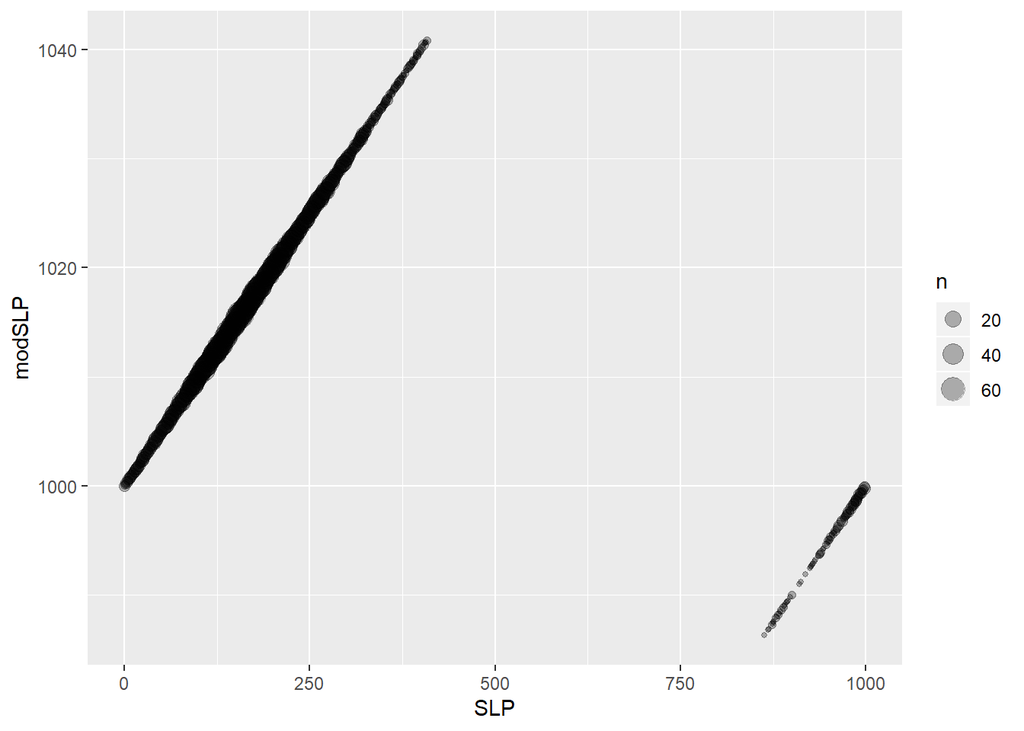

```r
# Correct for SLP
dfParse <- dfParse %>%
    mutate(modSLP=ifelse(dfParse$SLP < 500, 1000 + dfParse$SLP/10, 900 + dfParse$SLP/10))

dfParse %>%
    group_by(SLP, modSLP) %>%
    summarize(n=n()) %>%
    ggplot(aes(x=SLP, y=modSLP, size=n)) +
    geom_point(alpha=0.3)
```

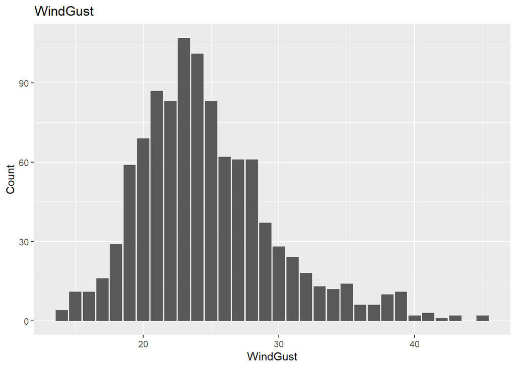

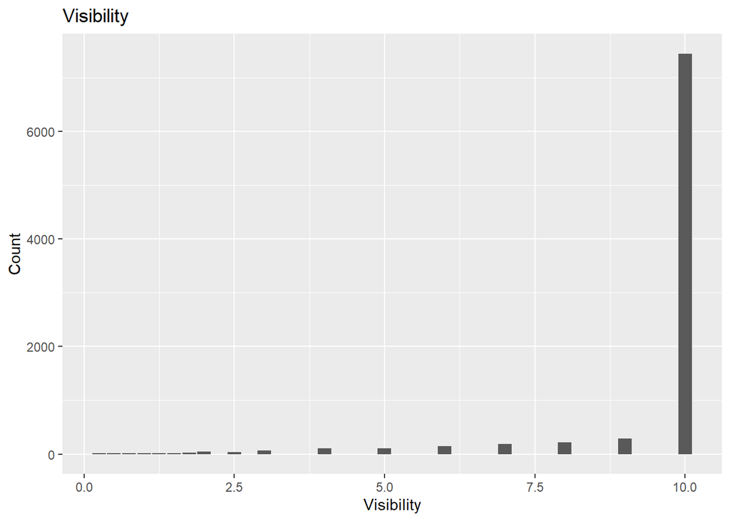

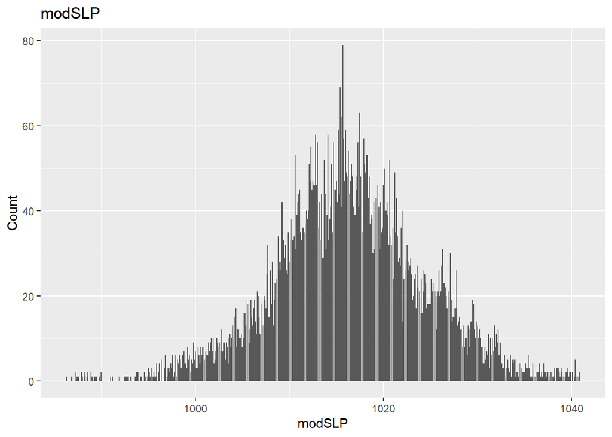

```r
# Check updated plots
keyMetric <- c("WindGust", "Visibility", "modSLP")
for (x in keyMetric) {
    p <- dfParse %>%
        group_by_at(vars(all_of(x))) %>%
        summarize(n=n()) %>%
        ggplot(aes_string(x=x, y="n")) +
        geom_col() +
        labs(title=x, y="Count")
    print(p)
}
```